# Article Title

**Table 2: Frequency of Comorbidities by ART Failure**

[output not shown]

**Concurrent Disease Burden and Antiretroviral Response:** Co-occurring infectious pathologies displayed strong correlations with treatment effectiveness (Table 2). Pulmonary tuberculosis prevalence was substantially higher among treatment-inadequate participants (24.5%) versus treatment-adequate individuals (14.1%, p<0.001). Diabetic conditions showed increased occurrence in treatment-inadequate cases (13.1%) compared to treatment-adequate participants (7.4%, p=0.071), nearing significance thresholds. Hepatitis B/C viral coinfections occurred more frequently among treatment-failure participants (8.9%) than treatment-adequate cases (4.3%, p=0.012) (Table 2).

**Table 3: ART Failure Rates Across Multimorbidity Categories**

[output not shown]

**Table 4: Multivariable Logistic Regression Analysis of Factors Associated with ART Failure in HIV-Positive Patients (N = 2709)**

[output not shown]

our – Unadjusted Odds Ration ; aOR – Adjusted Odds Ratio

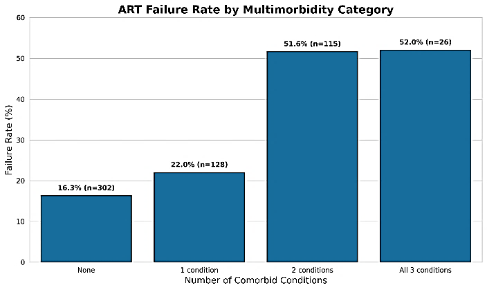

**Figure 2: ART Failure Rates Across Multimorbidity Categories Among People Living with HIV (N = 2709)**

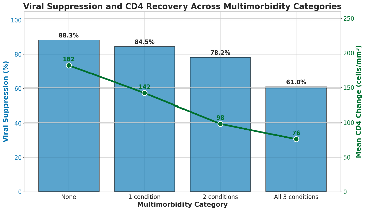

**Figure 3: Viral Suppression and Mean CD4 Recovery by Multimorbidity Category**

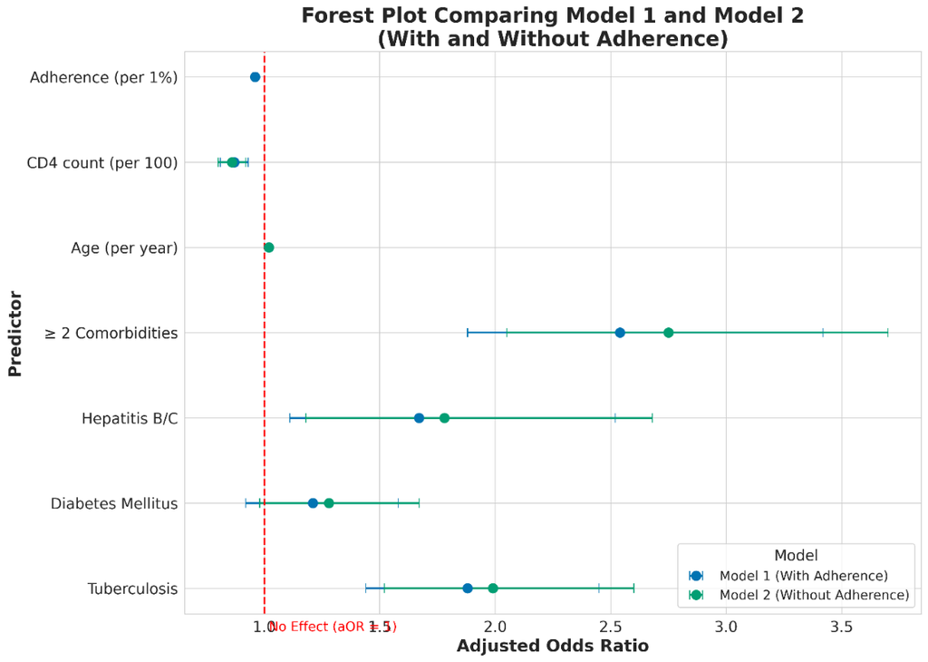

**Figure 4: Multivariate Analysis of Factors Associated with ART Failure in HIV-Positive Individuals**

**Multi-morbidity Spectrum and Treatment Effectiveness:** Increasing comorbidities disease burden correlated with declining therapeutic success (Table 3, Figure 2). Participants with no comorbidity had the least amount of treatment inadequacy at 16.3% (302/1854 cases). Inadequacy rates rose to 22.0% (128/582 participants) with single-comorbidity presence. Dual-comorbidity prevalence significantly increased inadequacy to 51.6% (115/223). Participants with triple-comorbidity showed the highest sub-optimal level (52.0% [26/50 cases]) (Table 3, Figure 2).

Immune system recovery correlated inversely with disease multiplicity (Table 3, Figure 3). Average CD4+ cell gains were greatest among disease-free participants (+182 cells/mm³), declining progressively: single-disease (+142 cells/mm³), dual-disease (+98 cells/mm³), triple-disease (+76 cells/mm³) (Table 3, Figure 3).

Comparison of the two multivariable models demonstrated partial mediation by adherence. When adherence was excluded (Model 2), the effect estimates for tuberculosis (aOR 1.88 to 1.99), hepatitis B/C (1.67 to 1.78), and multimorbidity (2.54 to 2.75) increased, indicating that part of their association with ART failure operates through reduced adherence. Diabetes showed a borderline increase (aOR 1.21 to 1.28; p=0.075). Age and CD4 count remained stable across both models, suggesting independence from adherence-related pathways. (Table 4)

**Autonomous Risk Determinant Assessment:** Multivariate regression identified independent treatment inadequacy predictors (Table 4, Figure 4). Pulmonary tuberculosis coinfection constituted significant risk with adjusted odds ratio 1.88 (95% CI: 1.44-2.45, p<0.001). Hepatitis B/C coinfections showed adjusted odds ratio 1.67 (95% CI: 1.11-2.52, p=0.012). Diabetic conditions exhibited risk elevation without significance (adjusted odds ratio 1.21, 95% CI: 0.92-1.58, p=0.154) (Table 4, Figure 4).

Dual-plus comorbidity presence represented the strongest autonomous predictor with adjusted odds ratio 2.54 (95% CI: 1.88-3.42, p<0.001) (Table 4, Figure 4). Increasing age elevated inadequacy probability 2% annually (adjusted odds ratio 1.02, 95% CI: 1.01-1.03, p=0.001) (Table 4).

Protective elements included higher initial CD4+ concentrations, with each 100-cell/mm³ elevation reducing inadequacy risk 13% (adjusted odds ratio 0.87, 95% CI: 0.81-0.93, p<0.001). Superior medication compliance provided protection, with each 1% compliance improvement reducing inadequacy risk 4% (adjusted odds ratio 0.96, 95% CI: 0.95-0.97, p<0.001) (Table 4, Figure 4).

**DISCUSSION**

Our results are consistent with new evidence from LMICs on the rising impact of multimorbidity on HIV care outcomes. Emerging evidence from low- and middle-income countries indicates that people living with HIV (PLHIV) who have age-associated comorbidities for example, cardiovascular, renal, metabolic or other chronic non-communicable diseases (NCDs) are more likely to experience sub-optimal HIV treatment outcomes, such as virological or immunological failure. This growing burden of multimorbidity underscores the need for integrated care models that address comorbid conditions alongside HIV.<sup>11,14</sup> More recent analyses from India also highlight a growing burden of metabolic and non-communicable comorbidities among people living with HIV; this evolving multimorbidity may compromise long-term HIV care and underscores the need for integrated HIV-NCD services.<sup>15,16</sup> In line with these findings, our results highlight that multimorbidity significantly compromises the impact of first-line ART regimes in programme settings.

Socio-demographic factors such as younger age, lower education, and low income/unstable earning have been shown to drive ART non-adherence in urban HIV care settings as posited by Sangeda et al.<sup>20</sup> The growing prevalence of comorbidities and multimorbidity among people living with HIV (PLHIV) forecast to reach around 70% by 2030 in the United States underscores that health systems will increasingly be required to manage more complex patients, as previously reported by Althoff and co-workers<sup>2</sup>. Adherence continued to be an important modifiable factor with failure risk decreasing by 4% per percentage point improved adherence; however, it decreased with increasing multimorbidity suggesting that a one-size-fits-all approach may not be appropriate. Innovative, patient-centred interventions such as digital adherence tools and peer mentoring approach need to be scaled up, in conjunction with simplified regimens although effective early diagnosis of HIV infection and prompt ART initiation are also important, with evidence that higher baseline CD4+ counts translated to improved outcome.

**STUDY LIMITATIONS**

Several methodological limitations constrain the interpretation of our results: the retrospective design does not permit establishment of causal inferences, and unmeasured confounding factors cannot be excluded. Single-center recruitment means that our results are potentially not generalizable across different types of healthcare settings and study populations. Furthermore, limitations of our data did not enable adjustment for antiretroviral regimen differences, treatment duration differences and detailed adherence measures.

**CONCLUSION**

In this large Indian public-sector cohort, we demonstrate a strong, dose-dependent increase in ART failure with accumulating tuberculosis, diabetes, and chronic viral hepatitis. Individuals with two or more of these comorbidities represent a high-risk group who need priority attention within national HIV programmes. Strengthened adherence counselling, routine screening and treatment for hepatitis, and differentiated service delivery models are essential in efforts to improve outcomes and deal with an increasing burden of multimorbidity among people living with HIV.

Future research should target prospective cohort design to assess longitudinal associations of comorbidity onset with treatment outcome. Prospective randomized controlled trials testing integrated care interventions for multimorbid patients with HIV are of high research concern and of considerable interest to the community in order for observational results to be translated into evidence-based practice.

**POLICY IMPLICATIONS**

These results have significant implications for the national HIV programme and health system planning in India. Given the rising prevalence of multimorbidity in people living with HIV, incorporation of comorbidity assessment into routine risk stratification at ART centres may help identify individuals likely to require intensified, comprehensive care a need underscored by recent reviews on HIV-multimorbidity, as per intensified service models proposed by Sukumaran et al.<sup>21</sup> Patients with two or more comorbidities would require priority of adherence reinforcement, the use of digital tools, and differentiated service delivery; systematic screening for hepatitis and diabetes at the time of ART initiation and follow-up should be promoted. Harmonized care cascade for PLHIV specially impacted by multi-morbidity, ageing and institutionalization should be promoted. Age-associated non-communicable diseases be added to the care cascade as they become part of routine longitudinal treatment monitoring.<sup>22</sup> Comprehensive researcher‐provider and policy discussions might help determine how best researchers can contribute to such programme efforts. The implications for future policy and service delivery initiatives are that holistic, patient-centred care pathways targeting the range of chronic conditions simultaneously to improve long-term outcomes.

**Individual Authors’ Contributions: NPH** was responsible for conceptualization, methodology, investigation, data curation, formal analysis, and drafting the original manuscript. **PRW** provided supervision, validation, resources, project administration, and contributed to reviewing and editing the manuscript. **SB** contributed to software development, data curation, formal analysis, visualization, and modelling.

**Availability of Data:** De-identified data collected and analysed during this study are available from the corresponding author on reasonable request.

**Declaration of Non-use of Generative AI Tools:** This article was prepared without the use of generative AI tools for content creation, analysis, or data generation. All findings and interpretations are based solely on the authors' independent work and expertise.

**REFERENCES**

1. UNAIDS. Global HIV & AIDS statistics Fact sheet 2024. Geneva: Joint United Nations Programme on HIV/AIDS; 2024. Available from: https://www.unaids.org/en/resources/fact-sheet [Accessed on December 01, 2025]
2. Althoff KN, Stewart C, Humes E, Gerace L, Boyd C, Gebo K, Justice AC, . The forecasted prevalence of comorbidities and multimorbidity in people with HIV in the United States through the year 2030: A modeling study. PLoS Med. 2024 Jan 12;21(1):e1004325. DOI: https://doi.org/10.1371/journal. pmed.1004325 PMID: 38215160 PMCID: PMC10833859
3. Zerihun E, Tesema K, Abera F. Virological treatment failure and associated factors among adults on first-line antiretroviral therapy in West Hararghe, Ethiopia. Front Public Health. 2025 Jun 2;13:1440504. DOI: https://doi.org/10.3389/fpubh.2025. 1440504 PMid:40529669 PMCid:PMC12171124
4. Ross JL, Rupasinghe D, Chanyachukul T, Crabtree Ramírez B, Murenzi G, Kwobah E, et al. Comorbidities and HIV-related factors associated with mental health symptoms and unhealthy substance use among older adults living with HIV in low- and middle-income countries: a cross-sectional study. J Int AIDS Soc. 2025;28(3):e26434. DOI: https://doi.org/10.1002/ jia2.26434 PMid:40045453 PMCid:PMC11882396
5. McCutcheon K, Nqebelele U, Murray L, Thomas TS, Mpanya D, Tsabedze N. Cardiac and Renal Comorbidities in Aging People Living With HIV. Circ Res. 2024 May 24;134(11):1636-1660. DOI: https://doi.org/10.1161/CIRCRESAHA.124.323948
6. Weber MSR, Duran Ramirez JJ, Hentzien M, Cavassini M, Bernasconi E, Hofmann E, et. al; Swiss HIV Cohort Study. Time trends in causes of death in people with HIV: insights from the Swiss HIV Cohort Study. Clin Infect Dis. 2024;79(1):177-188. DOI: https://doi.org/10.1093/cid/ciae014 PMid:38214897 PMCid:PMC11259222
7. Giri S, Sahu P, Kanungo S, Bal HB, Kumar S, Kar S, Mohanty T, Turuk J, Das D, Hota PK, Pati S. Diabetes mellitus and human immunodeficiency virus (HIV) infection in people with tuberculosis in Odisha, India. Indian J Tuberc. 2024;71(2):147-152. DOI: https://doi.org/10.1016/j.ijtb.2023.04.021
8. World Health Organization. Module 6: Tuberculosis and comorbidities [Internet]. Geneva: World Health Organization; 2024. Available from: https://www.who.int/publications/i/ item/9789240087002. [Accessed on December 05, 2025]
9. Prakoeswa FRS, Maharani F, Bestari RS, et al. Aging and HIV: Recent Findings in Contributing Factors. AIDS Res Treat. 2025 Apr 11;2025:8814760. DOI: https://doi.org/10.1155/arat/ 8814760 PMID: 40255985 PMCID: PMC12008487
10. World Health Organization. Fact Sheet: HIV Drug Resistance. 2025. Available from: https://www.who.int/news-room/fact-sheets/detail/hiv-drug-resistance [Accessed on December 01, 2025]
11. Ahn MY, Jiamsakul A, Khusuwan S, Khol V, Pham TT, Chaiwarith R, et. Al, The influence of age-associated comorbidities on responses to combination antiretroviral therapy in older people living with HIV. J Int AIDS Soc. 2019 Feb;22(2):e25228. DOI: https://doi.org/10.1002/jia2.25228 PMid:30803162 PMCid:PMC6389354
12. Assemie MA, Alene M, Ketema DB, Mulatu S. Treatment failure and associated factors among first line patients on highly active antiretroviral therapy in Ethiopia: a systematic review and meta-analysis. Glob Health Res Policy. 2019;4:32. DOI: https://doi.org/10.1186/s41256-019-0120-4 PMid:31687474 PMCid:PMC6820995
13. Dessie G, Mulugeta H, Wagnew F, Zegeye A, Kiross D, et al. Immunological treatment failure among adult patients receiving highly active antiretroviral therapy in East Africa: a systematic review and meta-analysis. Curr Ther Res Clin Exp. 2021;94:100621. DOI: https://doi.org/10.1016/j.curtheres. 2020.100621 PMid:34306262 PMCid:PMC8296083
14. Abie A, Damessa M. The influence of age-associated comorbidities on responses to combination antiretroviral therapy among people living with HIV at the ART clinic of Jimma Medical Center, Ethiopia: A hospital-based nested case-control study. HIV AIDS (Auckl). 2023;15:457-475. DOI: https://doi. org/10.2147/HIV.S421523 PMid:37583543
15. Hamid S, Badyal A, Sumberia V. Point prevalence of metabolic syndrome in HIV positive patients. J Family Med Prim Care. 2024 Apr;13(4):1328-1332. DOI: https://doi.org/10.4103/ jfmpc.jfmpc_1237_23 PMID: 38827683 PMCID: PMC11141984
16. Sakthivel M, Jayaseelan V, Chinnakali P, Hamide A, Surendran G, Krishnamoorthy Y. Prevalence of Selected Cardiovascular Risk Factors and Their Associated Factors among People Living with HIV/AIDS in India. Indian J Community Med. 2024 Mar-Apr;49(2):308-315. DOI: https://doi.org/10.4103/ijcm. ijcm_583_22 PMID: 38665444 PMCID: PMC11042137
17. Tiberi S, du Plessis N, Walzl G, Vjecha MJ, et al. Tuberculosis: progress and advances in development of new drugs, treatment regimens, and host-directed therapies. Lancet Infect Dis. 2018 Jul;18(7):e183-e198. DOI: https://doi.org/10.1016/ S1473-3099(18)30110-5. Erratum in: Lancet Infect Dis. 2018 Jun;18(6):598. DOI: https://doi.org/10.1016/S1473-3099(18)30283-4. PMID: 29580819.
18. Meintjes G, Stek C, Blumenthal L, Thienemann F, Schutz C, Buyze J, Ravinetto R, van Loen H, Nair A, Jackson A, Colebunders R, Maartens G, Wilkinson RJ, Lynen L; PredART Trial Team. Prednisone for the Prevention of Paradoxical Tuberculosis-Associated IRIS. N Engl J Med. 2018 Nov 15;379(20): 1915-1925. DOI: https://doi.org/10.1056/NEJMoa1800762 PMid:30428290
19. van Griensven J, Phirum L, Choun K, Thai S, De Weggheleire A, Lynen L. Hepatitis B virus and Hepatitis C virus co-infection among HIV-infected adults on antiretroviral treatment: long-term survival, CD4 cell count recovery and ART-related hepatotoxicity in Cambodia. PLoS One. 2014;9(2):e88552. DOI: https://doi.org/10.1371/journal.pone.0088552 PMid:24533106 PMCid:PMC3922870
20. Sangeda RZ, Mosha F, Aboud S, Kamuhabwa A, Chalamilla G, Vercauteren J, et al. Predictors of non-adherence to antiretroviral therapy at an urban HIV care and treatment center in Tanzania. Drug Healthc Patient Saf. 2018;10:79-88. DOI: https://doi.org/10.2147/DHPS.S143178 PMid:30174460
21. Sukumaran L, Sabin CA. Defining multimorbidity in people with HIV what matters most? Curr Opin HIV AIDS. 2023;18(2): 59-67. DOI: 10.1097/COH.0000000000000778
22. McCombe G, Lim J, Van Hout MC, Lazarus JV, Bachmann M, Jaffar S, et al. Integrating Care for Diabetes and Hypertension with HIV Care in Sub-Saharan Africa: A Scoping Review. Int J Integr Care. 2022;22(1):6. DOI: https://doi.org/10.5334/ ijic.5839 PMid:35136387 PMCid:PMC8815447